# Modeling Health Data with Random Forest Classification

**Complete by: Tuesday 1 Apr. at class time**  
Data: https://jrladd.com/CIS241/data/500_Cities_small.csv

What does it mean for a *place* to be healthy? What can we learn about the overall health of people in the United States by looking at health by city and locality? These are the questions that the CDC's [PLACES](https://www.cdc.gov/places/about/index.html) project attempts to answer. This project originally began in 2015 as the "500 Cities Project": an annual survey of the 500 largest cities in the US. By surveying these cities every year, the CDC hopes to better understand long-term health among Americans all across the country.

As we continue through the COVID-19 pandemic, data analysis focused on health and healthcare continues to be at the center of public conversation. Good data analysis in this domain is essential for public health in the 21st century. In this week's workshop, you'll examine recent data from the PLACES project to better understand American's overall health.

***For this workshop, you will make a coherent and readable report. As you go through each section, make sure you are explaining, describing and interpreting all code, visualizations, and statistical output. The goal is that a reader with no previous knowledge of the data should be able to understand your findings.***

## Exploring Data with Decision Trees

While a random forest approach is best for accurate classification overall, individual decision trees are useful for exploring the data and understanding how variables interact.

- Import the necessary libraries. Which parts of sklearn will you need? What won't you need?
- Read the data as a CSV using the link above.
- Using sklearn's `DecisionTreeRegressor`, fit a decision tree model to the data set. Use `Physical Health` as your target.
- *Keep in mind all the steps that will go into this: preparing and splitting the data, standardizing the data, and fitting the model.*
- Create a visualization of the decision tree. It should look like this one (the Penguins example from Tuesday):

[figure not shown]

- Sci-kit learn has a built-in function to make these tree diagrams. Make sure it has colors and labels for each variable, just like the example above. You'll also need to make the figure size larger to make this readable.
- Find the feature importances for your decision tree.
- **Write an interpetation of your decision tree. What does it tell you about the relationships between your variables? Which variables seem most important? Will this help you determine hyperparameters when you fit your random forest regressorr?**

## Random Forest Regression

Once again what we want to know is: how healthy are people in different cities overall? If we had information on a new city, could we predict how healthy the people in that city might be?

- Use `Physical Health` as your target variable. This variable does ***not*** indicate that people are healthy. **Write down what this variable actually means.** You can check the PLACES documentation that I linked to above.
- Next choose some predictor variables. **Use the decision tree diagram above to help you narrow down which predictors to use.** *Remember, if you use categorical variables that will generate hundreds of columns in your one-hot encoded data, that will slow down your model and likely cause your kernel to overload!*
- Run a Random Forest regression using these predictors and targets. Make sure you've scaled the variables and done all appropriate pre-processing. **Explain your steps and interpret the results fully.**
- Use out-of-sample validation to check your model's residuals and calculate some appropriate measures. **How did your model perform? How did it compare to the KNN regression you ran last time?**

## Classifying Data with the Random Forest

We still want to know if the health of people in certain cities varies strongly by state. Given information about a new city, could we correctly predict the state in which it's located? Let's see if we can get better results with the Random Forest than we did with KNN.

- Use `StateAbbr` as your target. But **there are too many states to reasonably interpret the results**. As you did last time, narrow it down to just the two states with more than 40 cities in our data.
- Before you begin modeling, **create a decision tree diagram for your classifier just like you did for the regressor above. Interpret the diagram fully and choose your predictor variables based on what the diagram tells you.**
- Run a Random Forest classification using your chosen predictors and target. Make sure you've scaled the variables and done all appropriate pre-processing. **Explain your steps and interpret the results fully.**
- Find the variable importance of each predictor. **Interpret these fully. Which variables were most important and why? Did this surprise you or not, based on what you learned from the decision tree?**
- Use out-of-sample validation to check your model's confusion matrix, calculate appropriate measures, cross-validate, and make some visualizations. **How well did your model perform? How did it compare to the KNN classifier from last time?** (Keep in mind that we couldn't do an ROC curve on Tuesday because we didn't have a binary classifier, but *this* classifier will be binary.)

## Conclusion

Write a brief summary of what you learned about American cities through this analysis. Did your random forest models perform better than KNN? Why or why not? What other approaches might you recommend? Is there additional data on cities that you might want to add to this analyis?

## Exploring Data with Decision Trees

```python
import pandas as pd # Data Analysis
import numpy as np # Numerical Calculations
import altair as alt # Data Visualization

from sklearn.model_selection import train_test_split, cross_val_score
# These replace the r-squared score and RMSE
from sklearn.metrics import mean_squared_error, r2_score
# You could put these all on one line
from sklearn.metrics import RocCurveDisplay, confusion_matrix, classification_report
# You'll also need matplotlib this time
import matplotlib.pyplot as plt

from sklearn import tree
from sklearn.inspection import DecisionBoundaryDisplay
from sklearn.tree import DecisionTreeClassifier, DecisionTreeRegressor, plot_tree
from sklearn.ensemble import RandomForestClassifier, RandomForestRegressor
```

For this workshop, I will need to import the usual metrics and model selctions, which are `train_test_split`, `cross_val_score`, `mean_squared_error`, `r2_score`, `RocCurveDisplay`, `confusion_matrix`, and `classification_report`. I will need to import these because this information will help me validate the results of my models. In addition, I will need to import the `tree` library, along with `DecisionBoundaryDisplay`, `DecisionTreeClassifier`, `DecisionTreeRegressor`, `plot_tree`, `RandomForestClassifier`, and `RandomForestRegressor`. As this project requires me to use decision trees and random forests as models, these libraries are the necessary tools needed complete the workshop.

Since I am using decision trees and random forests, the other model types, such as `LinearRegression`, `KNN_Classifier`, and `naive_bayes` are unnecessary.

```python
health = pd.read_csv("https://jrladd.com/CIS241/data/500_Cities_small.csv")
health
```

|  | StateAbbr | CityName | Annual Checkup | Arthritis | Binge Drinking | COPD | Cancer (except skin) | Cholesterol Screening | Chronic Kidney Disease | Colorectal Cancer Screening | ... | Mammography | Mental Health | Obesity | Pap Smear Test | Physical Health | Physical Inactivity | Sleep <7 hours | Stroke | Taking BP Medication | Teeth Loss |
| --- | --- | --- | --- | --- | --- | --- | --- | --- | --- | --- | --- | --- | --- | --- | --- | --- | --- | --- | --- | --- | --- |
| 0 | AK | Anchorage | 52.403509 | 19.601754 | 20.208772 | 4.538596 | 5.464912 | 71.698246 | 2.359649 | 61.336842 | ... | 71.077193 | 11.529825 | 34.263158 | 78.859649 | 10.822807 | 20.908772 | 31.268421 | 2.307018 | 61.277193 | 13.161404 |
| 1 | AL | Birmingham | 74.820652 | 29.544565 | 11.909783 | 9.017391 | 5.865217 | 80.786957 | 3.920652 | 65.059783 | ... | 83.170652 | 16.438043 | 40.329348 | 84.966304 | 16.582609 | 36.742391 | 40.894565 | 4.941304 | 77.365217 | 21.410870 |
| 2 | AL | Hoover | 71.206667 | 25.520000 | 15.490000 | 5.633333 | 6.720000 | 83.743333 | 2.433333 | 72.453333 | ... | 80.853333 | 11.570000 | 29.160000 | 85.520000 | 10.630000 | 24.326667 | 33.323333 | 2.356667 | 73.500000 | 8.651724 |
| 3 | AL | Huntsville | 71.501667 | 29.518333 | 13.165000 | 8.163333 | 6.845000 | 80.790000 | 3.260000 | 70.596667 | ... | 80.235000 | 14.961667 | 35.896667 | 82.798333 | 14.641667 | 30.871667 | 38.216667 | 3.705000 | 74.886667 | 15.925000 |
| 4 | AL | Mobile | 75.018182 | 30.684416 | 13.237662 | 9.251948 | 6.387013 | 80.054545 | 3.866234 | 63.827632 | ... | 82.017105 | 16.787013 | 38.803896 | 85.270130 | 16.635065 | 37.114286 | 40.011688 | 4.709091 | 77.664935 | 21.703947 |
| ... | ... | ... | ... | ... | ... | ... | ... | ... | ... | ... | ... | ... | ... | ... | ... | ... | ... | ... | ... | ... | ... |
| 495 | WI | Milwaukee | 72.525701 | 22.728972 | 22.527103 | 6.160748 | 5.046729 | 76.326636 | 3.408879 | 60.386449 | ... | 81.111682 | 16.138785 | 35.874299 | 84.768692 | 14.083178 | 30.293458 | 39.897196 | 3.706542 | 72.440654 | 22.051869 |
| 496 | WI | Racine | 69.333333 | 23.987500 | 23.533333 | 5.995833 | 6.000000 | 78.350000 | 3.112500 | 63.012500 | ... | 77.820833 | 13.766667 | 39.504167 | 82.533333 | 13.020833 | 25.745833 | 39.679167 | 3.275000 | 71.945833 | 17.162500 |
| 497 | WI | Waukesha | 69.186364 | 22.995455 | 24.295455 | 4.590909 | 6.177273 | 79.800000 | 2.454545 | 66.790909 | ... | 78.168182 | 11.559091 | 30.763636 | 82.972727 | 10.040909 | 20.640909 | 33.227273 | 2.331818 | 70.822727 | 11.072727 |
| 498 | WV | Charleston | 80.350000 | 35.725000 | 11.879167 | 11.104167 | 7.391667 | 83.012500 | 3.495833 | 69.054167 | ... | 80.208333 | 16.362500 | 39.287500 | 85.775000 | 16.325000 | 29.908333 | 40.129167 | 3.916667 | 79.550000 | 23.783333 |
| 499 | WY | Cheyenne | 64.755556 | 23.416667 | 17.188889 | 6.105556 | 6.611111 | 74.961111 | 2.672222 | 60.411111 | ... | 72.644444 | 11.700000 | 29.205556 | 79.294444 | 10.866667 | 25.977778 | 33.261111 | 2.733333 | 70.105556 | 14.611111 |

500 rows × 30 columns

```python
target = "Physical Health"
predictors = ["Annual Checkup", "Cholesterol Screening", "High Blood Pressure", "Obesity", "Sleep <7 hours"]
```

This line of code shows my predictor variables, which are `Annual Checkup`, `Cholesterol Screening`, `High Blood Pressure`, `Obesity`, and `Sleep <7 hours` as predictors of the `Physical Health` variable, which is the proportion of people who struggle to perform basic daily tasks.

```python
reg = tree.DecisionTreeRegressor()
```

This line of code creates the DecisionTreeRegressor

```python
health = health.dropna(subset = predictors + [target])
X=health[predictors]
y=health[target]
X_train, X_test, y_train, y_test = train_test_split(
    X,
    y,
    test_size=0.3,
    random_state=42)
```

This line of code assigns the predictors to the `X` variable and the target to the `y` for the decision tree model. This code also splits the data into training and testing portions.

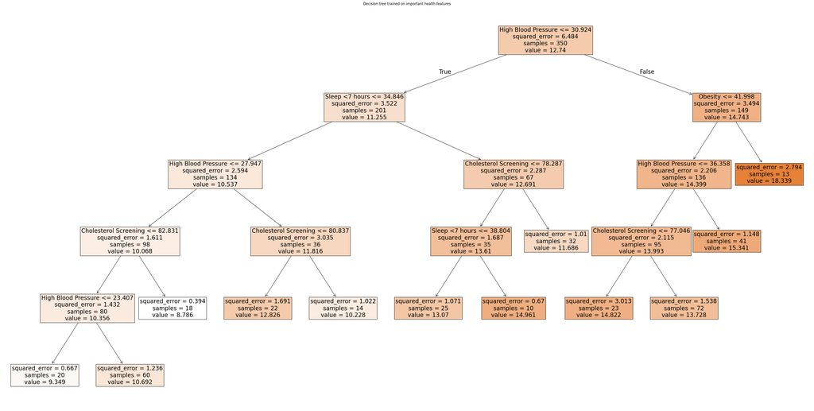

```python
plt.figure(figsize = [50, 25])
reg = DecisionTreeRegressor(max_leaf_nodes=12, min_samples_leaf=3,criterion="squared_error",random_state=42).fit(X_train, y_train)
feature_names = reg.feature_names_in_
plot_tree(reg, filled=True, fontsize = 20, feature_names = feature_names, class_names=y)
plt.title("Decision tree trained on important health features")
plt.show()
```

```python
for f,i in zip(feature_names, reg.feature_importances_):
    print(f,i)
```

```
Annual Checkup 0.0
Cholesterol Screening 0.09850717007974746
High Blood Pressure 0.6690958603910795
Obesity 0.10267099440842001
Sleep <7 hours 0.1297259751207531
```

The variables with the greatest importance include `High Blood Pressure`, `Obesity`, and `Sleep <7 hours`. These variables will help determine hyperparamters when I fit my random forest regressor because they will make the model more accurate.

## Random Forest Regression

According to the PLACES documentation, `Physical Health` checks for individuals that have the ability to function properly, engage in physical activity, and maintain a healthy lifestyle, ultimately promoting overall health and preventing disease. Contrary to one's assumptions, the `health` dataset checks for the proportion of people who do not have the ability to function properly, engage in physical activity, and maintain a healthy lifestyle.

```python
target = "Physical Health"
predictors_regF = ["High Blood Pressure", "Obesity", "Sleep <7 hours"]
```

This line of code shows my new predictor variables that I chose based on their importance, which are `High Blood Pressure`, `Obesity`, and `Sleep <7 hours` as predictors of the `Physical Health` variable, which is the proportion of people who struggle to perform basic daily tasks.

```python
X_forest=pd.get_dummies(health[predictors_regF])
y_forest=health[target]

X_trainF, X_testF, y_trainF, y_testF = train_test_split(
    X_forest,
    y_forest,
    test_size=0.3,
    random_state=42)
```

This line of code assigns the predictors with the highest importance (i.e. `High Blood Pressure`, `Obesity`, and `Sleep <7 hours`) to the `X_forest` variable and the target to the `y_forest` for the random forest model. Much like the decision tree model, this code also splits the data into training and testing portions.

```python
forest = RandomForestRegressor(max_leaf_nodes=12,min_samples_leaf=3,criterion="squared_error",random_state=42)
```

This line of code creates the random forest model with a maximum number of leaves of 12, a minimum number of samples per leaf being 3, measuring its results based on "squared error", and setting its seed to 42 for consistency.

```python
forest.fit(X_trainF,y_trainF)
```

```
RandomForestRegressor(max_leaf_nodes=12, min_samples_leaf=3, random_state=42)
```

This line of code fits the forest model based on the training data from the predictor and target variables.

```python
predictions_reg = forest.predict(X_testF)
```

This line of code predicts the proportionality of individuals with poor physical health in new cities based on the test data.

```python
residuals = y_testF - predictions_reg
residuals
```

```
361   -0.021770
73     0.414089
374   -0.526658
155    0.895394
104   -0.021704
         ...
266    0.053069
23     2.022834
222    1.393857
261    0.485424
426   -2.126312
Name: Physical Health, Length: 150, dtype: float64
```

I ran a residual test to see if the actual values of the `Physical Health` statistic are similar to the ones my model predicted. After analyzing the results, I can tell that my model did a good job of predicting the `Physical Health` variable. This is because the values of the residuals are close to 0.

```python
print(f"Root mean squared error: {np.sqrt(mean_squared_error(y_testF, predictions_reg)):.2f}")
```

```
Root mean squared error: 1.34
```

This line of code calculates the Root Mean Squared Error (RMSE for short) because it allows me to determine the accuracy of my model's performance. In this case, the RMSE is 1.34. Since most of the values in `Physical Health` range from 10.0-20.0, this means that my model performed relatively well in predicting which variables led to a proportion of individuals with poor physical health.

```python
print(f"Coefficient of determination: {r2_score(y_testF, predictions_reg):.2f}")
```

```
Coefficient of determination: 0.70
```

I ran a calculation to determine the Coefficient of determination for my model. I did this to measure how strong my predicted values were compared to the actual results. Because my value is 0.70, I can deduce that there is a small amount variation from the actual values of the proportionality of individuals with poor physical health.

```python
results = pd.DataFrame({"predictions":predictions_reg, "residuals":residuals})
results = results.dropna() # Drop all rows that have NaNs.
results
```

|  | predictions | residuals |
| --- | --- | --- |
| 361 | 12.467053 | -0.021770 |
| 73 | 11.880505 | 0.414089 |
| 374 | 12.783325 | -0.526658 |
| 155 | 9.993494 | 0.895394 |
| 104 | 12.564562 | -0.021704 |
| ... | ... | ... |
| 266 | 11.142931 | 0.053069 |
| 23 | 12.632005 | 2.022834 |
| 222 | 12.456143 | 1.393857 |
| 261 | 15.119576 | 0.485424 |
| 426 | 10.100597 | -2.126312 |

150 rows × 2 columns

I created the `results` DataFrame to determine if the histogram of residuals follows a normal distribution. This dataframe combines the `predictions` and `residuals` variables so that the histogram will be easier to code.

```python
alt.Chart(results, title="Histogram of Residuals").mark_bar().encode(
    x=alt.X('residuals:Q', title="Residuals").bin(maxbins=20),
    y=alt.Y('count():Q', title="Value Counts")
)
```

[interactive chart not shown]

This line of code creates the actual histogram for analysis. Looking at the histogram, I can tell that the `residuals` variable is not normally distributed for positive residual values. The residuals measure the difference between actual and predicted values for the `Physical Health` statistic, whereas the Value Counts determines the frequency of the residuals' values. Based on these results, most residuals had a similar value to the actual results of the data. This means that the results are reliable, meaning that my predictor variables caused my model to perform well when predicting the proportion of individuals from new cities that have poor physical health.

```python
scores_reg = cross_val_score(forest, X_forest, y_forest, cv=5)
print(f"{scores_reg.mean():.2} accuracy with standard deviation {scores_reg.std():.2}")
```

```
0.64 accuracy with standard deviation 0.084
```

I ran the random forest regressor model 5 more times to determine if it was accurate across multiple simulations. After running this model 5 more times, the average "accuracy" of this model is 0.64, meaning that the model performs worse across various simulations. Also, the standard deviation of the 5 test models is 0.084, meaning the values of the results are very close together. Taking into account my initial test, this model has a mediocre performance across various simulations. When comparing this model to my KNN model, this out-of-sample validation performs worse than the KNN model. However, since the KNN model ran poorly, this means that my random forest model was a slight improvement.

## Classifying Data with the Random Forest

```python
twoStates = health[(health["StateAbbr"] == "CA") | (health["StateAbbr"] == "TX")]
twoStates
```

|  | StateAbbr | CityName | Annual Checkup | Arthritis | Binge Drinking | COPD | Cancer (except skin) | Cholesterol Screening | Chronic Kidney Disease | Colorectal Cancer Screening | ... | Mammography | Mental Health | Obesity | Pap Smear Test | Physical Health | Physical Inactivity | Sleep <7 hours | Stroke | Taking BP Medication | Teeth Loss |
| --- | --- | --- | --- | --- | --- | --- | --- | --- | --- | --- | --- | --- | --- | --- | --- | --- | --- | --- | --- | --- | --- |
| 24 | CA | Alameda | 65.800000 | 19.116667 | 18.311111 | 4.255556 | 6.133333 | 82.005556 | 2.616667 | 71.250000 | ... | 79.011111 | 10.083333 | 20.338889 | 81.827778 | 9.588889 | 16.927778 | 33.777778 | 2.411111 | 68.472222 | 7.977778 |
| 25 | CA | Alhambra | 68.836364 | 15.963636 | 13.300000 | 3.950000 | 5.040909 | 82.022727 | 2.990909 | 58.722727 | ... | 77.295455 | 10.077273 | 17.754545 | 78.590909 | 10.850000 | 22.354545 | 37.890909 | 2.763636 | 70.877273 | 9.340909 |
| 26 | CA | Anaheim | 65.031169 | 15.997403 | 19.314286 | 4.780519 | 4.942857 | 78.089610 | 2.828571 | 62.348052 | ... | 78.585714 | 12.929870 | 22.733766 | 81.679221 | 11.744156 | 22.058442 | 33.911688 | 2.540260 | 64.388312 | 12.959740 |
| 27 | CA | Antioch | 64.968182 | 19.540909 | 18.463636 | 5.595455 | 5.377273 | 78.586364 | 2.900000 | 66.618182 | ... | 78.240909 | 14.013636 | 27.718182 | 82.877273 | 12.404545 | 21.700000 | 35.954545 | 2.813636 | 67.136364 | 12.768182 |
| 28 | CA | Apple Valley | 69.971429 | 26.385714 | 17.000000 | 7.628571 | 7.207143 | 80.385714 | 3.542857 | 62.928571 | ... | 80.357143 | 14.378571 | 31.264286 | 82.407143 | 14.621429 | 25.600000 | 37.878571 | 3.735714 | 70.657143 | 17.214286 |
| ... | ... | ... | ... | ... | ... | ... | ... | ... | ... | ... | ... | ... | ... | ... | ... | ... | ... | ... | ... | ... | ... |
| 451 | TX | San Antonio | 63.720447 | 19.906070 | 18.855272 | 5.298403 | 5.339936 | 77.873482 | 3.231949 | 57.804792 | ... | 77.980511 | 13.826837 | 34.724920 | 82.310863 | 13.415655 | 34.483387 | 35.104792 | 2.995847 | 71.088818 | 14.786901 |
| 452 | TX | Sugar Land | 70.245000 | 19.515000 | 16.425000 | 3.825000 | 5.925000 | 84.465000 | 2.370000 | 65.425000 | ... | 78.110000 | 9.050000 | 24.230000 | 79.185000 | 8.880000 | 24.215000 | 31.915000 | 2.240000 | 73.875000 | 7.040000 |
| 453 | TX | Tyler | 68.141379 | 22.786207 | 16.662069 | 6.662069 | 6.248276 | 77.372414 | 3.355172 | 58.020690 | ... | 76.713793 | 14.679310 | 35.479310 | 78.475862 | 13.624138 | 33.203448 | 35.710345 | 3.682759 | 72.558621 | 18.371429 |
| 454 | TX | Waco | 67.100000 | 21.737838 | 17.016216 | 6.894595 | 5.570270 | 74.281081 | 3.381081 | 57.564865 | ... | 75.391892 | 16.335135 | 37.164865 | 80.035135 | 14.310811 | 35.659459 | 35.024324 | 3.643243 | 69.040541 | 20.154054 |
| 455 | TX | Wichita Falls | 69.436364 | 26.948485 | 16.724242 | 7.403030 | 6.169697 | 77.596970 | 3.312121 | 58.760606 | ... | 76.787879 | 15.275758 | 39.384848 | 80.324242 | 14.706061 | 36.351515 | 38.951515 | 3.642424 | 72.893939 | 16.236364 |

168 rows × 30 columns

This line of code creates a subset of the `health` dataframe that includes the only two states with more than 40 cities, which are California and Texas.

```python
target_clf = "StateAbbr"
```

This line of code sets the target variable to `StateAbbr` for my classifier model.

```python
predictors2 = ["Obesity", "Physical Inactivity", "High Cholesterol", "Cancer (except skin)", "Current Smoking"]
```

This line of code shows my predictor variables for the classifier decision tree, which are `Obesity`, `High Cholesterol`, `Cancer (except skin)`, `Physical Inactivity`, and `Current Smoking`.

```python
clf = tree.DecisionTreeClassifier()
```

This line of code creates the Classifier Decision Tree

```python
twoStates = twoStates.dropna(subset = predictors2 + [target_clf])
X2=pd.get_dummies(twoStates[predictors2])
y2=twoStates[target_clf]
X_train2, X_test2, y_train2, y_test2 = train_test_split(
    X2,
    y2,
    test_size=0.35,
    random_state=42)
```

This line of code assigns the predictors of my classifier decision tree to the `X2` variable and the target variable of my classifier models to the `y2` for this decision tree. This code also splits the data into training and testing portions.

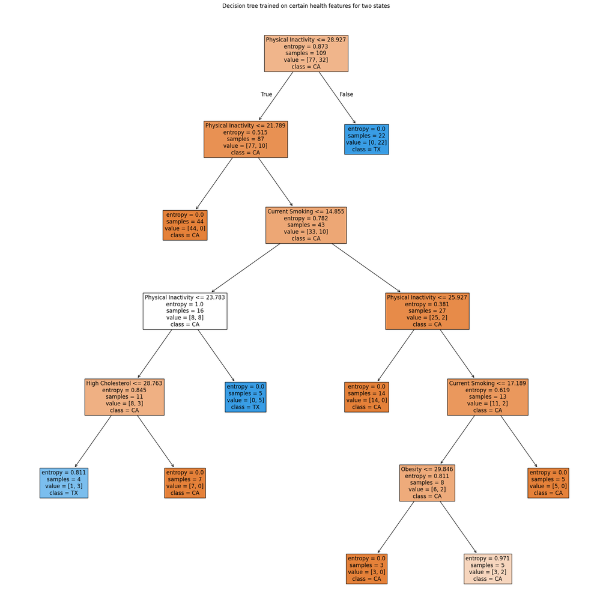

```python
plt.figure(figsize = [24, 24])
clf = DecisionTreeClassifier(max_leaf_nodes=12, min_samples_leaf=3, criterion='entropy',random_state=42).fit(X_train2, y_train2)
feature_names = clf.feature_names_in_
categories = clf.classes_
plot_tree(clf, filled=True, fontsize = 12, feature_names = feature_names, class_names=categories)
plt.title("Decision tree trained on certain health features for two states")
plt.show()
```

This decision tree begins with its first variable as `Physical Inactivity`. Because of this, I can assume that `Physical Inactivity` will be an important feature for my random forest. Based on the decision, this model predicts that a high number of individuals with lack of activity will be located in Texas. Conversely, this means that a low proportion of individuals with a lack of physical activity are located in California. However, if between 22 - 29% of individuals lack physical activity, the decision tree then checks for the proportion of people who currently smoke. After determining which proportion of people from a particular state are phyiscally inactive, the decision tree begins to determine a correlation between `Current Smoking` and `Physical Inactivity`. The decision tree continues to determine correlation between `Physical Inactivity` and Smoking; it predicts that most individuals with a lack of physical activity but a higher proportion of smoking live in California.

After the decision tree detects no correlation between lack of physical activity and smoking, it then checks for a correlation between `Physical Inactivity` and `High Cholesterol`. If the proportion of `Physical Inactivity` is high enough, the decision tree predicts that these individuals live in Texas. Otherwise, it then checks for individuals who are physically active but have high cholesterol. If the proportionality of individuals who have high cholesterol is large enough, the tree predicts that these individuals live in California, and live in Texas otherwise.

Lastly, `Obesity` plays a limited factor in this decision tree, meaning that it is not an important feature for my random forest model.

Because `Physical Inactivity` and `Current Smoking` are located near the top of the decision tree, they will be the predictors for my random forest classifier model, and is shown in the line of code below.

```python
predictors_clf = ["Physical Inactivity", "Current Smoking"]
```

```python
X_clf=pd.get_dummies(twoStates[predictors_clf])
y_clf=twoStates[target_clf]

X_trainC, X_testC, y_trainC, y_testC = train_test_split(
    X_clf,
    y_clf,
    test_size=0.35,
    random_state=42)
```

This line of code assigns the most important predictors of my classifier decision tree (which were `Physical Inactivity` and `Current Smoking`) to the `X_clf` variable and the target variable of my classifier models (`StateAbbr`) to the `y_clf` for this random forest classifier. This code also splits the data into training and testing portions.

```python
forest2 = RandomForestClassifier(max_leaf_nodes=12,min_samples_leaf=3,criterion="entropy",random_state=42)
```

This line of code creates the random forest model with a maximum number of leaves of 12, a minimum number of samples per leaf being 3, measuring its results based on "entropy", and setting its seed to 42 for consistency.

```python
forest2.fit(X_trainC,y_trainC)
```

```
RandomForestClassifier(criterion='entropy', max_leaf_nodes=12,
                       min_samples_leaf=3, random_state=42)
```

This line of code fits the classifier random forest model based on the training data from the predictor and target variables.

```python
probabilities_f = forest2.predict_proba(X_testC)
probabilities_f = pd.DataFrame(probabilities_f)

predictions_f = forest2.predict(X_testC)
```

This line of code creates the `predictions_f` variable based on the predictions that the classifier random forest model makes based on the test data to determine if a data point is located in California or Texas.

```python
categories_f = forest2.classes_
```

I created the `categories_f` variable to determine if my chosen statistics fall under California or Texas.

```python
# Calculate confusion matrix and transform data
conf_mat = confusion_matrix(y_testC,predictions_f)
conf_mat = pd.DataFrame(conf_mat,index=categories_f,columns=categories_f)
conf_mat = conf_mat.melt(ignore_index=False).reset_index()
conf_mat
```

|  | index | variable | value |
| --- | --- | --- | --- |
| 0 | CA | CA | 42 |
| 1 | TX | CA | 3 |
| 2 | CA | TX | 2 |
| 3 | TX | TX | 12 |

In this step, I created a confusion matrix to determine how well the model performed. This confusion matrix is based on the testing data for my target variable, as well as the predictions my model made.

```python
# Create heatmap
heatmap = alt.Chart(conf_mat).mark_rect().encode(
    x=alt.X("variable:N").title("Predicted Response"),
    y=alt.Y("index:N").title("True Response"),
    color=alt.Color("value:Q", legend=None).scale(scheme="blues")
).properties(
    width=400,
    height=400
)
# Add text labels for numbers
text = heatmap.mark_text(baseline="middle").encode(
    text=alt.Text("value:Q"),
    color=alt.value("black"),
    size=alt.value(50)
)

heatmap + text
```

[interactive chart not shown]

```python
print(classification_report(y_testC, predictions_f))
```

```
              precision    recall  f1-score   support

          CA       0.93      0.95      0.94        44
          TX       0.86      0.80      0.83        15

    accuracy                           0.92        59
   macro avg       0.90      0.88      0.89        59
weighted avg       0.91      0.92      0.91        59
```

In this step, I calculated the scores for my model based on accuracy, precision, recall, and specificity. Based on these results, I can conclude that the model performed well. This is because the accuracy was 0.92, meaning 92% of cases were classified correctly. The model's precision shows that 93% of the predicted values in California correct, whereas only 86% of the predicted values in Texas were correct. Based on the recall and specificity scores, the model has 95% recall, which is great. The model also has a specificity score of 80, meaning that 80% of all values in Texas were correctly classified. This is much better when comparing it to my KNN Model from the previous workshop.

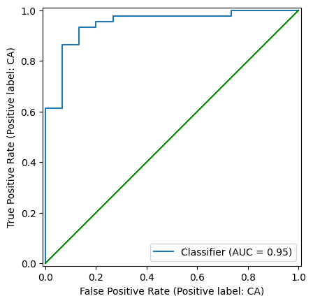

```python
# Create our ROC Curve plot
RocCurveDisplay.from_predictions(y_testC,
                                 probabilities_f[0],
                                 pos_label=categories_f[0])

# Draw a green line for 0
plt.plot([0, 1], [0, 1], color = 'g')
```

This code creates an ROC Curve to determine the peformance of my random forest classification model using an AUC (Area under the curve) score. In this case, the AUC score for this curve is 0.95. Based on these metrics, the model performed well and further validates my conclusion that the model is reliable.

```python
for f,i in zip(feature_names, clf.feature_importances_):
    print(f,i)
```

```
Obesity 0.01877917516571638
Physical Inactivity 0.8092712421212107
High Cholesterol 0.06951166929963053
Cancer (except skin) 0.0
Current Smoking 0.10243791341344247
```

The line of code above determines the importance of my chosen predictor variables for my classifier decision tree. According to my decision tree, `Physical Inactivity`, and `Current Smoking` are the most important variables because they are located near the top of the tree. This does not surprise me because the purpose of the decision tree is to tell you how to determine which variables are the most important before and after running a model. `Cancer (except skin)` has a value of 0.0 because it is nowhere to be found in the decision tree.

```python
scores_clf = cross_val_score(forest2, X_clf, y_clf, cv=5)
print(f"{scores_clf.mean():.2} accuracy with standard deviation {scores_clf.std():.2}")
```

```
0.89 accuracy with standard deviation 0.016
```

In this step, I ran cross-validation of the random forest classification model to determine if the model itself was accurate across multiple simulations. I chose to run 5 more models with different training and test data. The results show that on average, the model itself is accurate 89% of the time with a standard deviation score of 0.016. This means that the model itself is very good when predicting if specific health issues occur in California or Texas. When comparing this model to the KNN model from last time, the random forest classifier didn't peform as well because its cross-validation accuracy is lower. However, its specificity is higher than that of the KNN model, meaning that both models are acceptable measures of predicting if a city with specific health issues is located in Texas or California.

## Conclusion

Based on my research, American cities have a number of health issues, including Obesity, Cancer, Smoking, and Arthritis, just to name a few. Obesity and High Cholesterol tend to be associated with health threats to American citizens. I have also learned that Texas has a higher proportion of individuals that are physically inactive as opposed to California. However, California has a higher proportion of individuals who smoke regularly.

Going forward, I would recommend choosing different variables for my decision trees to see if they produce better or worse results than what were calculated in this workshop. I would also like to include more health-related issues to cities, such as exposure to pollutants, diet, and/or stress and anxiety.